# CSCI E-63C: Problem Set 4

# Problem: estimating multiple regression error rate by resampling (60 points)

This week problem set closely follows what was just explained in the preface, except that instead of using simulated dataset, you are expected to use the fundraising dataset that you have already worked with during the previous weeks. Note that the dataset now also has predicted values (column `predcontr`) for the outcome as described below. It is available on the course website in canvas (file `fund-raising-with-predictions.csv` on the Canvas page for this lecture).

The first column – `contrib` – is the outcome we are trying to predict. The last column – `predcontr` – represents *predictions* for that outcome variable made by one of the simpler models submitted by a participant in the data mining competition that used this fund raising dataset back in the 90’s. We will use the attribute `predcontr` only as a *reference* (we will compare it to our own models’ predictions). It has to be excluded from model building (it would not be prudent to try predicting the outcome using predictions already made for that same outcome by someone else - not in the settings of this assignment at least!).

The column before last – `gender` – is a categorical attribute that we will also omit for the purposes of this week problem set in the interests of simplicity. In the end you should be working with a dataset with twelve continuous attributes – one outcome, `contrib`, and eleven predictors (`gapmos`, `promocontr`, `mincontrib`, `ncontrib`, `maxcontrib`, `lastcontr`, `avecontr`, `mailord`, `mindate`, `maxdate` and `age`). Because of distributional properties of multiple attributes in this dataset, you are better off with log-transforming *both* predictors and the outcome. Because several values in this dataset are zeroes and in order to avoid dealing with NaNs, just add “1” before the log-transform to all values in this dataset (e.g. `myDat <- log(myDat+1)`).

## Sub-problem 1: prepare the dataset (10 points)

Read in the dataset, drop categorical attribute (`gender`) and predictions by the competition participants (`predcontr`), log-transform predictors and outcome as described above, rearrange columns in the dataset in the decreasing order of absolute values of their correlation with the outcome (`contrib`). So that in the resulting data table the outcome (`contrib`) is the first column, the next one is the predictor that is the most (positively or negatively) correlated with it, and so on. You may find it convenient to use R function `order` for that.

```r
#load data
fundata = read.table("fund-raising-with-predictions.csv", header = T, sep = ",")

#drop gender and competition predictions
variables = subset(fundata, select = -c(gender, predcontr))

#transform
logvar = log(variables + 1)

#rearrange
corr = (cor(logvar))
order = order(abs(corr[,1]), decreasing = T)
corr = corr[, order]
logvar = logvar[, order]
names(logvar) #check order
```

```
##  [1] "contrib"    "avecontr"   "lastcontr"  "maxcontrib" "mincontrib"
##  [6] "ncontrib"   "promocontr" "maxdate"    "gapmos"     "mindate"
## [11] "age"        "mailord"
```

## Sub-problem 2: add quadratic terms to the dataset (10 points)

Use the code presented in the preface as a template to develop your own procedure for adding to the fund raising dataset containing outcome (`contrib`) and all continuous predictors (`gapmos` through `age`) all pairwise products of continuous predictors (e.g. `gapmos` x `gapmos`, `gapmos` x `promocontr`, …, `age` x `age`). The data used here has to be the one from fund raising dataset, *not* simulated from normal distribution as shown in the preface. In the end your dataset should have 78 columns: `contrib`, 11 predictors and 11*12/2=66 of their pairwise combinations.

```r
predictors = subset(logvar, select = -c(contrib))

pairpred = NULL
tmpcolnames = NULL

for (i in 1:ncol(predictors)){

  for (j in i:ncol(predictors)){
    pairpred = cbind(pairpred,predictors[,i]*predictors[,j]) #calc pairwise products
    tmpcolnames = c(tmpcolnames, paste0(colnames(predictors[i])," x ", colnames(predictors[j]))) #pairwise column names
  }
}

pairpred = data.frame(pairpred)
colnames(pairpred) = tmpcolnames

logvar = cbind(logvar, pairpred) #add columns to dataset
ncol(logvar) #number of columns check
```

```
## [1] 78
```

## Sub-problem 3: fit multiple regression models on the entire dataset (10 points)

As illustrated in the preface above, starting from the first, most correlated with `contrib`, predictor, fit linear models with one, two, …, all 77 linear and quadratic terms on the entire dataset and calculate resulting (training) error for each of the models. Plot error as a function of the number of predictors in the model (similar to the plot in the preface that shows just the training error on the entire dataset). Also, indicate in the same plot the error from predicting all outcomes to be just the average outcome on the entire dataset as shown in the preface.

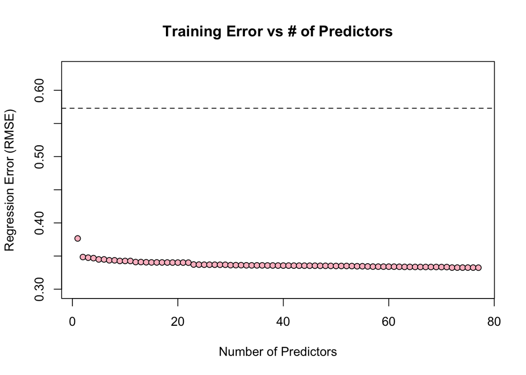

```r
err = NULL
for (n in 2:ncol(logvar)){
  multlm = lm(contrib ~ . , data = logvar[,1:n]) #fit models
  rmse =  sqrt(mean((logvar[, "contrib"]-predict(multlm))^2))
  err = rbind(err,data.frame((n-1),err=rmse)) #list # of predictors and RMSE
}

plot = plot(err, xlab = "Number of Predictors", ylab = "Regression Error (RMSE)", main = "Training Error vs # of Predictors", ylim=c(min(err[,"err"]) * 0.9,sqrt(mean((logvar[,"contrib"]-mean(logvar[,"contrib"]))^2)) * 1.1), pch = 21, bg = "pink")
abline(h=sqrt(mean((logvar[,"contrib"]-mean(logvar[,"contrib"]))^2)), lty = 2)
```

Because the underlying data is different, the change of the regression error with the number of attributes included in the model in the plot that you obtain here for fund raising dataset will be different from that shown in the preface. Please comment on this difference.

**The model generated from the data in the preface shows higher regression error, starting at nearly 1.1 with 1 predictor and then decreasing with the inclusion of more attributes. The fundraising model plot shows lower error, starting at approximately 0.38 with 1 predictor and decreasing very gradually with more predictors. The preface model also shows the highest regression error much closer to the error from predicting outcomes as the mean values from the dataset, compared to the fundraising model which shows much lower error in comparison. The preface model shows a steeper decline in regression error over the 27 variables it includes than the fundraising model.**

## Sub-problem 4: develop function performing bootstrap on fund raising dataset (10 points)

Modify function `bootTrainTestErrOneAllVars` defined in the preface to perform similar kind of analysis on the fund raising dataset. Alternatively, you can determine what modifications are necessary to the fund raising dataset, so that it can be used as input to `bootTrainTestErrOneAllVars`.

```r
bootTrainTestErrOneAllVars <- function(inpDat,nBoot=100) {
  # matrices to store bootstrap training and test errors; columns will correspond to
  # models with different numbers of variables included (from 1 through all of them) and
  # rows will correspond to bootstrap iterations; for instance, the errors of models with one and two variables
  # (Y~X1 and Y~X1+X2) will be found in columns 1 and 2, respectively, and those columns will
  # store nBoot values:
  errTrain <- matrix(NA,nrow=nBoot,ncol=ncol(inpDat)-1)
  errTest <- matrix(NA,nrow=nBoot,ncol=ncol(inpDat)-1)
  # vector to store the training error of each model
  # fitted on all observations:
  allTrainErr <- numeric()
  # this loop tries different models: with 1, 2, 3, ... predictor variables
  # (note that first predictor is the second column in
  # the input data - the first column is the outcome "Y"):
  for ( iTmp in 2:ncol(inpDat) ) {
    # fit model that inludes iTmp-1 first variables (in the order they occur
    # in the columns of inpDat):
    lmTmp <- lm(contrib~.,inpDat[,1:iTmp])

    # (use summary(lmTmp)$sigma if you want correction for the degrees of freedom)
    # training error of the current model (iTmp-1 predictors) fitted on all data:
    allTrainErr[iTmp-1] <- sqrt(mean((inpDat[,"contrib"]-predict(lmTmp))^2))

    # Now let's cross-validate the current model using bootstrap.
    # Perform nBoot intependent bootstrapping resamplings to accumulate the statistics:
    for ( iBoot in 1:nBoot ) {
      # in each resampling iteration, generate a new bootstrapped sample
      # (replace=TRUE is critical for bootstrap to work correctly!):
      tmpBootIdx <- sample(nrow(inpDat),nrow(inpDat),replace=TRUE)
      # now tmpBootIdx are the indexes of observations in the original data that were
      # randomly selected (in this particular bootstrap iteration) to be placed into the training set.
      # Now fit the current model on the bootstrap sample:
      lmTmpBoot <- lm(contrib~.,inpDat[tmpBootIdx,1:iTmp])
      # calculate the MSE for the current bootstrap iteration
      # (or use summary(lmTmpBoot)$sigma for degrees of freedom correction):
      errTrain[iBoot,iTmp-1] <- sqrt(mean((inpDat[tmpBootIdx,"contrib"]-predict(lmTmpBoot))^2))
      # test error is calculated on the observations
      # =not= in the bootstrap sample - thus "-tmpBootIdx"
      errTest[iBoot,iTmp-1] <- sqrt(mean((inpDat[-tmpBootIdx,"contrib"]-
                                            predict(lmTmpBoot,newdata=inpDat[-tmpBootIdx,1:iTmp]))^2))
    }
  }
  # return results (bootstrap training errors, bootstrap test errors, and training errors
  # claculated on the full dataset) as different slots in the list:
  list(bootTrain=errTrain,bootTest=errTest,allTrain=allTrainErr)
}
```

## Sub-problem 5: use bootstrap to estimate training and test error on fund raising dataset (20 points)

Use function developed above to estimate training and test error in modeling `contrib` for the fund raising dataset. Plot and discuss the results.

```r
boot = bootTrainTestErrOneAllVars(logvar)
```

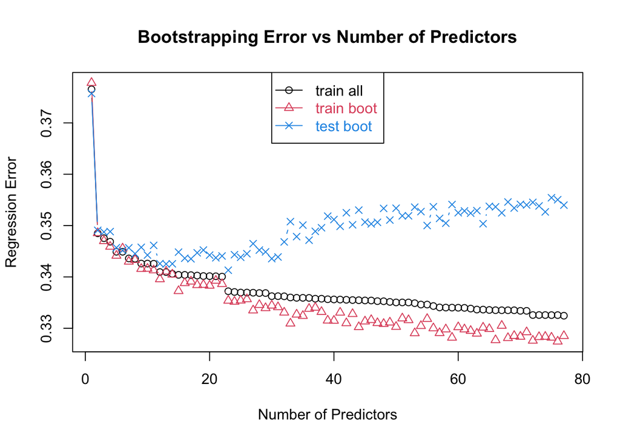

```r
plotboot <- function(inpRes,inpPchClr=c(1,2,4),...) {
  matplot(1:length(inpRes$allTrain),cbind(inpRes$allTrain,
                                          colMeans(inpRes$bootTrain),
                                          colMeans(inpRes$bootTest)
                                          ),
          pch=inpPchClr,col=inpPchClr,lty=1,type="b",xlab="Number of Predictors",ylab="Regression Error",...)
  legend("top",c("train all","train boot","test boot"),
         col=inpPchClr,text.col=inpPchClr,pch=inpPchClr,lty=1)
}

plotboot(boot,main="Bootstrapping Error vs Number of Predictors")
```

Compare your model errors obtained over the range of model complexity (in other words over the range of numbers of variables included) to the error of the model built by the competition participants (we know their predictions, so their residuals are differences between `contrib` and `predcontr` in the original full dataset; since we used the log-transform before proceeding with our own modeling, this needs accounted for – make sure that you either calculate the error of the competition participants on the same log scale or recalculate your own errors back to the original scale before the comparison!)

```r
logpredcontr = log(fundata$predcontr + 1)

comprmse = sqrt(mean(logvar[, "contrib"] - logpredcontr)^2)
paste("Competition Predictions RMSE:", round(comprmse, 4))
```

```
## [1] "Competition Predictions RMSE: 0.1077"
```

## Extra points problem: training and test error on subsets of the data (5 points)

Perform tasks specified above (using bootstrap to estimate training and test error), but applying them only to the first 200, 500 and 1000 observations in the fund raising dataset provided. Comment on how the behavior of training and test error across the range of model complexity changes with the change in the sample size. For the ease of comparisons and interpretation, please make sure that all three resulting plots (error vs. number of predictors) use the same limits for the vertical (Y) axis.

```r
boot200 = bootTrainTestErrOneAllVars(logvar[1:200,])
boot500 = bootTrainTestErrOneAllVars(logvar[1:500,])
boot1000 = bootTrainTestErrOneAllVars(logvar[1:1000,])
```

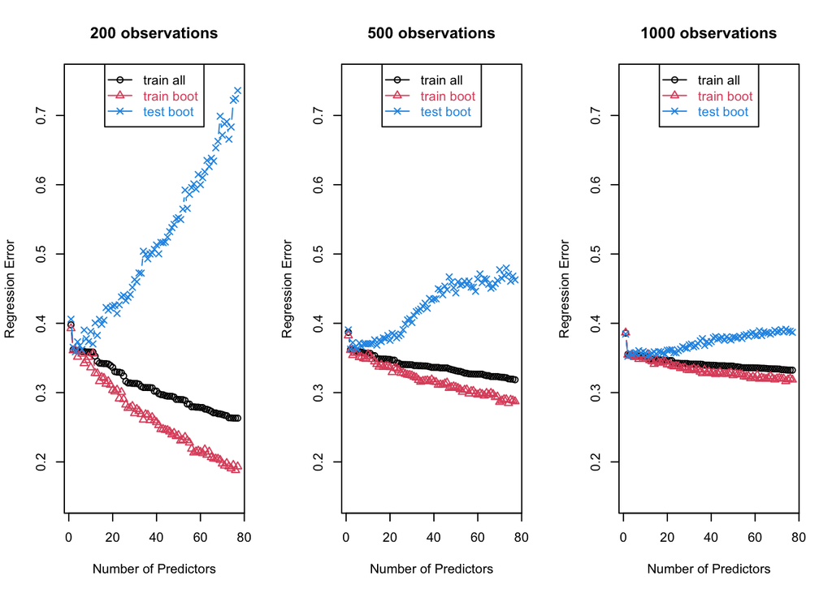

```r
par(mfrow = c(1,3))
plotboot(boot200,main="200 observations", ylim = c(0.15, 0.75))
plotboot(boot500,main="500 observations", ylim = c(0.15, 0.75))
plotboot(boot1000,main="1000 observations", ylim = c(0.15, 0.75))
```

**Smaller sample size results in a more significant difference between training and testing data as the number of predictors. As the sample size increases, the difference between training and testing error narrows. Testing error decreases and training error increases.**

## Extra points problem: using centered and scaled predictor values (5 points)

Given the undesirable effects of having highly correlated predictors in the model (for the reasons of collinearity, variance inflation, etc.) it would be more adviseable to center and scale predictors in this dataset prior to creating higher order terms. There is a function `scale` in R for that. Please explore the effect of using such transformation. You should be able to demonstrate that it does decrease correlations between predictors (including their products) while it has very little impact on the performance of the resulting models in terms of training/test error. If you think carefully about what is necessary here, the required change could be as small as adding one (optional) call to `scale` placed strategically in the code and then compiling and comparing results with and without executing it.

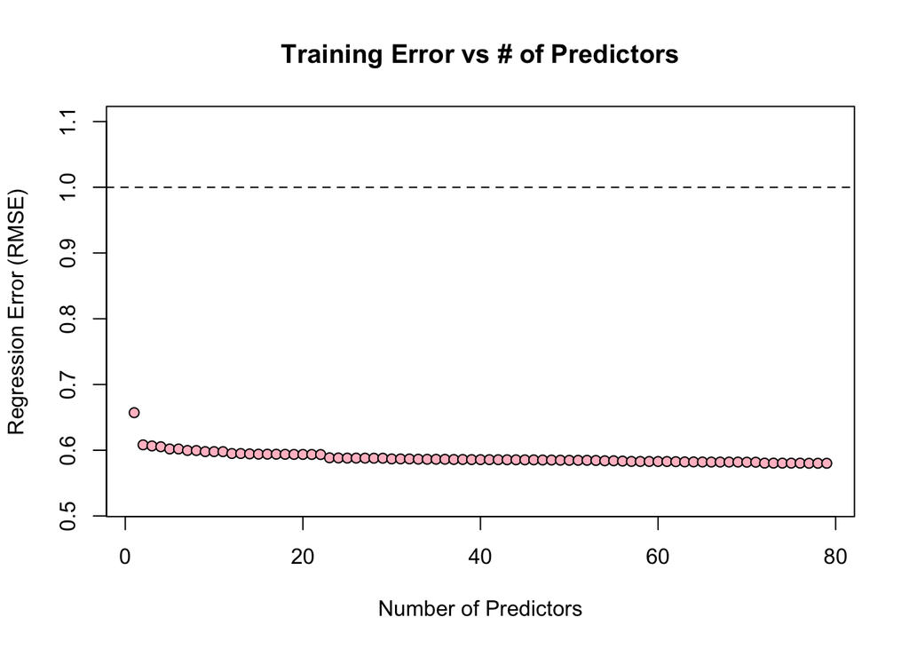

```r
scaled = data.frame(scale(logvar), center = T, scale = T)
scaledcor = cor(scale(logvar))

err = NULL
for (n in 2:ncol(scaled)){
  multlm = lm(contrib ~ . , data = scaled[,1:n]) #fit models
  rmse =  sqrt(mean((scaled[, "contrib"]-predict(multlm))^2))
  err = rbind(err,data.frame((n-1),err=rmse)) #list # of predictors and RMSE
}

plot = plot(err, xlab = "Number of Predictors", ylab = "Regression Error (RMSE)", main = "Training Error vs # of Predictors", ylim=c(min(err[,"err"]) * 0.9,sqrt(mean((scaled[,"contrib"]-mean(scaled[,"contrib"]))^2)) * 1.1), pch = 21, bg = "pink")
abline(h=sqrt(mean((scaled[,"contrib"]-mean(scaled[,"contrib"]))^2)), lty = 2)
```